# Ayudantía N°3

Juan Miño.

# Regresión Lineal Simple

```r
episodes <- readr::read_csv('https://raw.githubusercontent.com/rfordatascience/tidytuesday/master/data/2021/2021-11-23/episodes.csv')
head(episodes)
```

| era | season_number | serial_title | story_number | episode_number | episode_title | type | first_aired | production_code | uk_viewers | rating | duration |
| --- | --- | --- | --- | --- | --- | --- | --- | --- | --- | --- | --- |
| revived | 1 | NA | 157 | 1 | Rose | episode | 2005-03-26 | 1.1 | 10.81 | 76 | 45 |
| revived | 1 | NA | 158 | 2 | The End of the World | episode | 2005-04-02 | 1.2 | 7.97 | 76 | 44 |
| revived | 1 | NA | 159 | 3 | The Unquiet Dead | episode | 2005-04-09 | 1.3 | 8.86 | 80 | 44 |
| revived | 1 | NA | 160a | 4 | Aliens of London | episode | 2005-04-16 | 1.4 | 7.63 | 82 | 45 |
| revived | 1 | NA | 160b | 5 | World War Three | episode | 2005-04-23 | 1.5 | 7.98 | 81 | 42 |
| revived | 1 | NA | 161 | 6 | Dalek | episode | 2005-04-30 | 1.6 | 8.63 | 84 | 45 |

Supongamos que las variables no numéricas entorpecen el análisis. Filtraremos sólo las numéricas.

```r
num_episodes <- episodes[sapply(episodes, is.numeric)]
```

Crearemos un modelo que establece la cantidad de televidentes en UK en función del rating.

```r
modelo <- lm(uk_viewers ~ rating, data = num_episodes)
```

Calcularemos los coeficientes de la regresión.

```r
coeficientes <- coef(modelo)
coeficientes
```

```
## (Intercept)      rating
##  -8.0337160   0.1847694
```

Podemos graficar la recta de MCO que relaciona los espectadores en función del rating del episodio.

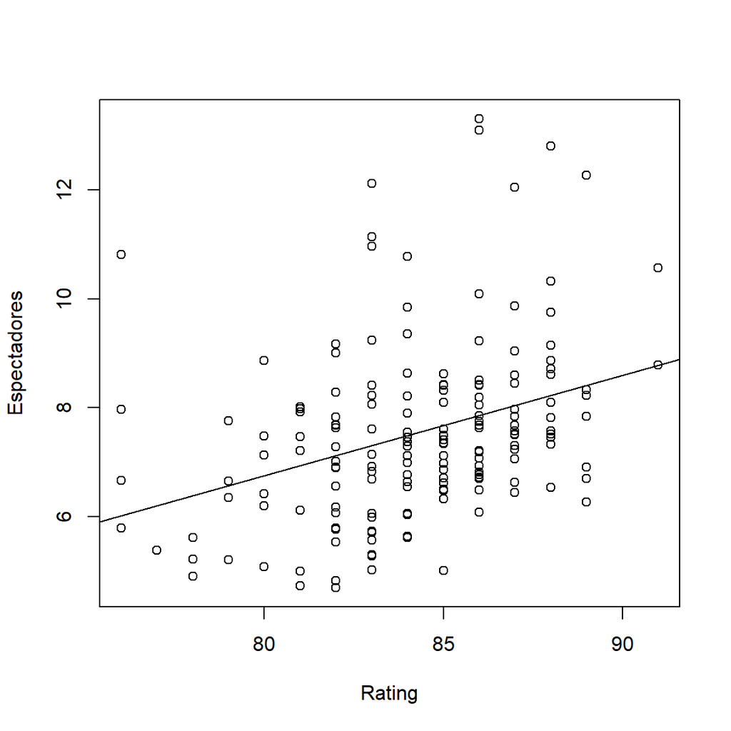

```r
plot(num_episodes$rating, num_episodes$uk_viewers, xlab='Rating', ylab='Espectadores')
abline(modelo)
```

Podemos notar una gran dispersión en los datos. También podemos notar que presentan una tendencia de pendiente positiva.

Pediremos un summary a RStudio para extraer mejores conclusiones.

```r
summary(modelo)
```

```
##
## Call:
## lm(formula = uk_viewers ~ rating, data = num_episodes)
##
## Residuals:
##     Min      1Q  Median      3Q     Max
## -2.6717 -1.0138 -0.2188  0.6409  5.4536
##
## Coefficients:
##             Estimate Std. Error t value Pr(>|t|)
## (Intercept) -8.03372    3.33318  -2.410    0.017 *
## rating       0.18477    0.03955   4.672 6.15e-06 ***
## ---
## Signif. codes:  0 '***' 0.001 '**' 0.01 '*' 0.05 '.' 0.1 ' ' 1
##
## Residual standard error: 1.546 on 165 degrees of freedom
##   (5 observations deleted due to missingness)
## Multiple R-squared:  0.1168, Adjusted R-squared:  0.1115
## F-statistic: 21.83 on 1 and 165 DF,  p-value: 6.149e-06
```

Podemos notar un R-squared demasiado bajo, equiparable al ajustado. Sin embargo el rating tiene una alta significancia.

En términos de significancia del modelo, F-statistic es bastante alto en comparación al valor p, que es cercano a 0.

La hipótesis nula ($H_0$) establece que el coeficiente $\beta_1$ es igual a cero (es decir, no hay relación entre $x$ e $y$) y la hipótesis alternativa ($H_1$) afirma que $\beta_1$ es diferente de cero.

Para HO: el beta es igual a 0, se rechaza H0. De hecho, ambas variables son significativas.

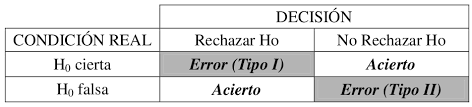

Para seguir trabajando con nuestro datos, convertiremos la variables NA (no available) de nuestra variable independiente a ceros.

```r
rating_na <- ifelse(is.na(num_episodes$rating), 0, num_episodes$rating)
num_episodes$rating <- rating_na
```

Podemos repetir este proceso para uk_viewers también.

```r
viewers_na <- ifelse(is.na(num_episodes$uk_viewers), 0, num_episodes$uk_viewers)
num_episodes$uk_viewers <- viewers_na
```

Ahora, calcularemos variables como la correlación.

```r
cor(num_episodes$uk_viewers,num_episodes$rating)
```

```
## [1] 0.6088849
```

Nuestro estadístico indica una correlación bastante alta entre variables. Nota: recordar que la correlación de Pearson utiliza la covarianza.

La fórmula para calcular la correlación de Pearson entre dos variables $X$ e $Y$ es:

$$\text{Cov}(X, Y) = \frac{{\sum_{i=1}^{n} (X_i - \bar{X})(Y_i -
\bar{Y})}}{{n - 1}}$$

$$\rho_{xy} = \frac{{\sum_{i=1}^{n} (X_i - \bar{X})(Y_i -
\bar{Y})}}{{\sqrt{\sum_{i=1}^{n} (X_i - \bar{X})^2 \sum_{i=1}^{n} (Y_i -
\bar{Y})^2}}}$$

Donde: - $n$ es el número de observaciones. - $X_i$ y $Y_i$ son los valores de la $i$-ésima observación en las variables $X$ e $Y$, respectivamente. - $\bar{X}$ y $\bar{Y}$ son las medias de las variables $X$ e $Y$ respectivamente. - $\rho_{XY}$ representa la correlación de Pearson entre las variables $X$ e $Y$.

Convertir en ceros no es del todo prudente en la mayoría de casos. Lo más prudente es por lo general buscar los datos faltantes o derechamente eliminarlos.

Añadiremos una segunda variable explicativa: duración del episodio

```r
modelo2 <- lm(uk_viewers ~ rating + duration, data = num_episodes)
```

Podemos analizar ambos modelos y compararlos.

```r
summary(modelo)
```

```
##
## Call:
## lm(formula = uk_viewers ~ rating, data = num_episodes)
##
## Residuals:
##     Min      1Q  Median      3Q     Max
## -2.6717 -1.0138 -0.2188  0.6409  5.4536
##
## Coefficients:
##             Estimate Std. Error t value Pr(>|t|)
## (Intercept) -8.03372    3.33318  -2.410    0.017 *
## rating       0.18477    0.03955   4.672 6.15e-06 ***
## ---
## Signif. codes:  0 '***' 0.001 '**' 0.01 '*' 0.05 '.' 0.1 ' ' 1
##
## Residual standard error: 1.546 on 165 degrees of freedom
##   (5 observations deleted due to missingness)
## Multiple R-squared:  0.1168, Adjusted R-squared:  0.1115
## F-statistic: 21.83 on 1 and 165 DF,  p-value: 6.149e-06
```

```r
summary(modelo2)
```

```
##
## Call:
## lm(formula = uk_viewers ~ rating + duration, data = num_episodes)
##
## Residuals:
##     Min      1Q  Median      3Q     Max
## -7.7383 -0.7693 -0.0145  0.8518  4.6715
##
## Coefficients:
##             Estimate Std. Error t value Pr(>|t|)
## (Intercept) -7.28076    1.54977  -4.698 5.48e-06 ***
## rating       0.11371    0.01576   7.215 1.83e-11 ***
## duration     0.10615    0.01591   6.673 3.57e-10 ***
## ---
## Signif. codes:  0 '***' 0.001 '**' 0.01 '*' 0.05 '.' 0.1 ' ' 1
##
## Residual standard error: 1.464 on 166 degrees of freedom
##   (3 observations deleted due to missingness)
## Multiple R-squared:  0.3633, Adjusted R-squared:  0.3556
## F-statistic: 47.36 on 2 and 166 DF,  p-value: < 2.2e-16
```

Claramente el modelo 2 tiene un mejor R-squared.

También podemos establecer un análisis de varianza para establecer la significancia de las variables de los modelos.

```r
anova(modelo)
```

|  | Df | Sum Sq | Mean Sq | F value | Pr(>F) |
| --- | --- | --- | --- | --- | --- |
| rating | 1 | 52.16181 | 52.161806 | 21.83092 | 6.148937e-06 |
| Residuals | 165 | 394.24349 | 2.389355 | NA | NA |

Si el valor p es menor que alpha, se rechaza la hipótesis nula. En este caso es menor y por tanto la hipótesis H0: La variable es no significante, se rechaza.

```r
anova(modelo2)
```

|  | Df | Sum Sq | Mean Sq | F value | Pr(>F) |
| --- | --- | --- | --- | --- | --- |
| rating | 1 | 107.48831 | 107.488313 | 50.17977 | 3.797741e-11 |
| duration | 1 | 95.39582 | 95.395818 | 44.53452 | 3.568811e-10 |
| Residuals | 166 | 355.58272 | 2.142065 | NA | NA |

La suma cuadrada de los residuales disminuye. El modelo se ajusta mejor a los datos reales. Además, ambas variables explicativas son altamente significantes.

Para testear la normalidad de los residuales de ambos modelos, podemos utilizar un QQPlot.

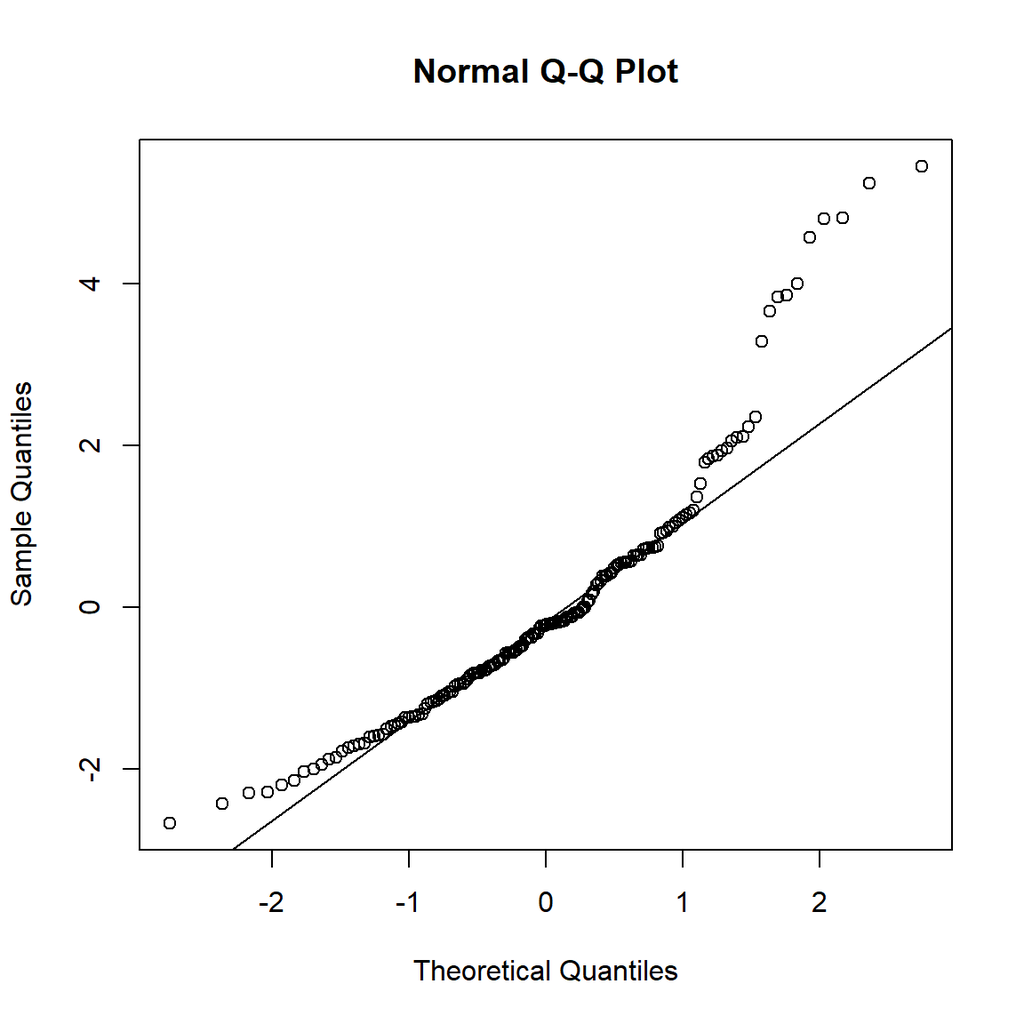

```r
qqnorm(modelo$residuals)
qqline(modelo$residuals)
```

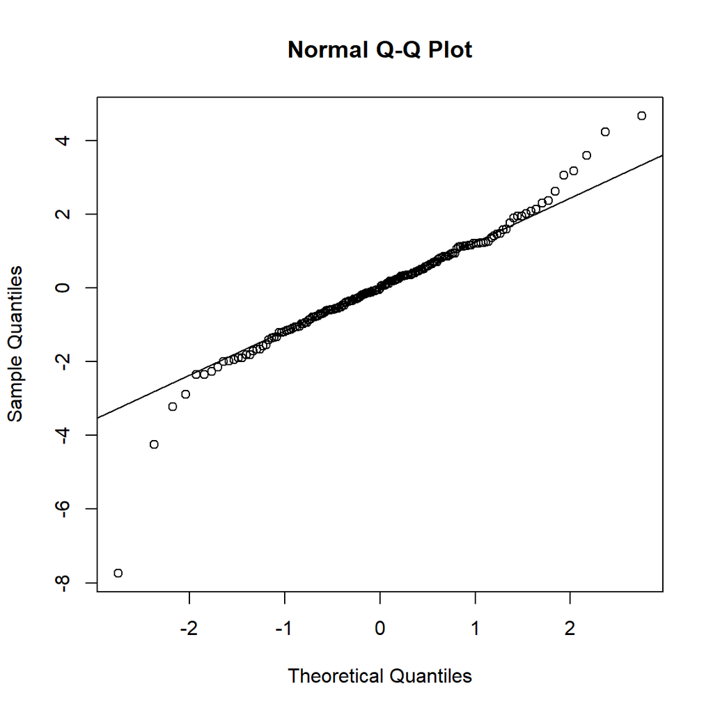

```r
qqnorm(modelo2$residuals)
qqline(modelo2$residuals)
```

# Enfoque de resultados potenciales

El enfoque de resultados potenciales es una herramienta utilizada en el campo de la causalidad para entender y evaluar el impacto causal de un tratamiento, intervención o variable en un grupo de estudio.

Supongamos que estamos investigando si un programa de tutorías tiene un efecto positivo en el rendimiento académico de los estudiantes. Queremos utilizar el enfoque de resultados potenciales para evaluar el impacto causal del programa de tutorías en las calificaciones finales de los estudiantes.

```r
# Cargamos las bibliotecas necesarias
library(dplyr)
library(ggplot2)

# Creamos un conjunto de datos ficticio
set.seed(123)
datos_potenciales <- data.frame(
  estudiante_id = 1:100,
  tratamiento = sample(c(0, 1), 100, replace = TRUE), # 0: Sin tutoría, 1: Con tutoría
  calificacion_inicial = rnorm(100, mean = 70, sd = 5)
)
```

Vamos a acceder a “calificacion_final” en el conjunto de datos “datos_potenciales”. Estamos creando una nueva columna en datos_potenciales donde almacenaremos las calificaciones finales simuladas.

- *with* función permite trabajar con las columnas del conjunto de datos datos_potenciales.
- $5 * tratamiento$ simboliza el efecto del tratamiento. Si tratamiento es 1, entonces habrá un incremento de 5 en la calificación final debido al tratamiento. Si tratamiento es 0, no habrá ningún cambio.
- *rnorm(100, mean = 0, sd = 3)*. Esto genera 100 números aleatorios que siguen una distribución normal con una media (mean) de 0 y una desviación estándar (sd) de 3. Estos números aleatorios representan el ruido o la variabilidad en las calificaciones finales.

En resumen, generaremos un proceso ficticio utilizado para ilustrar cómo se podría simular el efecto causal en un conjunto de datos.

```r
# Simulamos el efecto del tratamiento en las calificaciones
datos_potenciales$calificacion_final <- with(datos_potenciales, calificacion_inicial + 5 * tratamiento + rnorm(100, mean = 0, sd = 3))

# Agrupar los datos por tratamiento
datos_potenciales_grouped <- group_by(datos_potenciales, tratamiento)

# Calcular la media de calificacion_final para cada grupo
efecto_causal <- summarize(datos_potenciales_grouped, calificacion_media = mean(calificacion_final))

print(efecto_causal)
```

```
## # A tibble: 2 x 2
##   tratamiento calificacion_media
##         <dbl>              <dbl>
## 1           0               70.0
## 2           1               74.4
```